# HESA - SB252 (Student Statistics UK 2017/18)

```r
library(tidyverse)
library(ggvis)
```

# HESA - SB252 (Student Statistics UK 2017/18)

## Data import

Data downloaded from https://www.hesa.ac.uk/news/17-01-2019/sb252-higher-education-student-statistics

“This Statistical Bulletin is the annual first release of HESA student data. In previous years, our statistical bulletins were known as statistical first releases. We have changed the name to align with terminology used by other official statistics producers.

This bulletin covers higher education (HE) providers who submit a full Student record data return to HESA. This includes publicly funded Higher Education Institutions, the privately funded University of Buckingham, and HE level provision at Further Education (FE) Colleges in Wales (accounting for 1,670 students in 2017/18)."

```r
# import data, but exclude initial explanation rows
df <- read_csv("data/SB252_Student_UK_2017-18/figure-14.csv", skip = 17, col_names = TRUE)
df  # (134880 rows x 8 cols)
```

| Subject Area | First year marker | Level of study | Mode of study | Country of HE provider | Sex | Academic Year | Number |
| --- | --- | --- | --- | --- | --- | --- | --- |
| (1) Medicine & dentistry | All | All | Full-time | England | Female | 2013/14 | 24895 |
| (1) Medicine & dentistry | All | All | Full-time | England | Male | 2013/14 | 19410 |
| (1) Medicine & dentistry | All | All | Full-time | England | Other | 2013/14 | 0 |
| (1) Medicine & dentistry | All | All | Full-time | England | Total | 2013/14 | 44305 |
| (1) Medicine & dentistry | All | All | Full-time | England | Female | 2014/15 | 24835 |
| (1) Medicine & dentistry | All | All | Full-time | England | Male | 2014/15 | 19275 |
| (1) Medicine & dentistry | All | All | Full-time | England | Other | 2014/15 | 0 |
| (1) Medicine & dentistry | All | All | Full-time | England | Total | 2014/15 | 44110 |
| (1) Medicine & dentistry | All | All | Full-time | England | Female | 2015/16 | 25100 |
| (1) Medicine & dentistry | All | All | Full-time | England | Male | 2015/16 | 19290 |

[output cut: 990 more lines]

- `Subject Area` : (1-9, A-J, 3 totals)
- `First year marker` : ‘First year’/‘Other years’/All
- `Level of study` : (4 types, 2 sub-totals, total)
- `Mode of study` : Full-time/Part-time/All
- `Country of HE provider` : England/‘Northern Ireland’/Scotland/Wales/All
- `Sex` : Female/Male/Other/Total
- `Academic Year` : eg. 2013/14
- `Number` : quantity of students

## Data cleaning : rows

```r
# filter out rows that are totals. Note the use of `!` with `%in%` for lists
df <- df %>% filter(!`Subject Area` %in% c("Total", "Total - Non-science subject areas", "Total - Science subject areas")) %>% filter(`First year marker` != "All") %>% filter(!`Level of study` %in% c("All", "All postgraduate", "All undergraduate")) %>% filter(`Mode of study` != "All") %>% filter(`Country of HE provider` != "All") %>% filter(Sex != "Total")
df  # (17220 rows x 8 cols)
```

| Subject Area | First year marker | Level of study | Mode of study | Country of HE provider | Sex | Academic Year | Number |
| --- | --- | --- | --- | --- | --- | --- | --- |
| (1) Medicine & dentistry | First year | Postgraduate (research) | Full-time | England | Female | 2013/14 | 1045 |
| (1) Medicine & dentistry | First year | Postgraduate (research) | Full-time | England | Male | 2013/14 | 760 |
| (1) Medicine & dentistry | First year | Postgraduate (research) | Full-time | England | Other | 2013/14 | 0 |
| (1) Medicine & dentistry | First year | Postgraduate (research) | Full-time | England | Female | 2014/15 | 1075 |
| (1) Medicine & dentistry | First year | Postgraduate (research) | Full-time | England | Male | 2014/15 | 790 |
| (1) Medicine & dentistry | First year | Postgraduate (research) | Full-time | England | Other | 2014/15 | 0 |
| (1) Medicine & dentistry | First year | Postgraduate (research) | Full-time | England | Female | 2015/16 | 1135 |
| (1) Medicine & dentistry | First year | Postgraduate (research) | Full-time | England | Male | 2015/16 | 765 |
| (1) Medicine & dentistry | First year | Postgraduate (research) | Full-time | England | Other | 2015/16 | 0 |
| (1) Medicine & dentistry | First year | Postgraduate (research) | Full-time | England | Female | 2016/17 | 1000 |

[output cut: 990 more lines]

## Basic EDA

```r
# check that total still matches
df %>% count(Number)            # 1166 rows. `Number` is a multiple of 5. An odd rounding?
```

| Number | n |
| --- | --- |
| 0 | 6370 |
| 5 | 1050 |
| 10 | 647 |
| 15 | 447 |
| 20 | 429 |
| 25 | 347 |
| 30 | 324 |
| 35 | 230 |
| 40 | 223 |
| 45 | 205 |

[output cut: 990 more lines]

```r
df %>% nrow()                   # 17220 rows
```

```
[1] 17220
```

```r
df %>% summarize(sum(Number))   # 11506415 ...total of all 5 years
```

| sum(Number) |
| --- |
| 11506415 |

```r
df %>% group_by(`Academic Year`) %>% summarize(sum(Number))  # all a couple of '00 low ? (v's table on website)
```

| Academic Year | sum(Number) |
| --- | --- |
| 2013/14 | 2299305 |
| 2014/15 | 2265815 |
| 2015/16 | 2280670 |
| 2016/17 | 2317775 |
| 2017/18 | 2342850 |

```r
df %>% group_by(`Academic Year`, Sex) %>% summarize(sum(Number)) # 15 rows
```

| Academic Year | Sex | sum(Number) |
| --- | --- | --- |
| 2013/14 | Female | 1289090 |
| 2013/14 | Male | 1010090 |
| 2013/14 | Other | 125 |
| 2014/15 | Female | 1273210 |
| 2014/15 | Male | 992355 |
| 2014/15 | Other | 250 |
| 2015/16 | Female | 1288635 |
| 2015/16 | Male | 991690 |
| 2015/16 | Other | 345 |
| 2016/17 | Female | 1313985 |

[output cut: 5 more lines]

```r
df %>% group_by(`Academic Year`, `Subject Area`) %>% summarize(sum(Number))  # 95 rows. all +/- 5-30. (v's table on website)
```

| Academic Year | Subject Area | sum(Number) |
| --- | --- | --- |
| 2013/14 | (1) Medicine & dentistry | 67300 |
| 2013/14 | (2) Subjects allied to medicine | 273250 |
| 2013/14 | (3) Biological sciences | 207565 |
| 2013/14 | (4) Veterinary science | 5920 |
| 2013/14 | (5) Agriculture & related subjects | 18345 |
| 2013/14 | (6) Physical sciences | 93345 |
| 2013/14 | (7) Mathematical sciences | 42210 |
| 2013/14 | (8) Computer science | 91570 |
| 2013/14 | (9) Engineering & technology | 158980 |
| 2013/14 | (A) Architecture, building & planning | 49170 |

[output cut: 85 more lines]

```r
df %>% group_by(`Academic Year`, `Subject Area`, Sex) %>% summarize(sum(Number)) # 285 rows
```

| Academic Year | Subject Area | Sex | sum(Number) |
| --- | --- | --- | --- |
| 2013/14 | (1) Medicine & dentistry | Female | 37850 |
| 2013/14 | (1) Medicine & dentistry | Male | 29450 |
| 2013/14 | (1) Medicine & dentistry | Other | 0 |
| 2013/14 | (2) Subjects allied to medicine | Female | 217195 |
| 2013/14 | (2) Subjects allied to medicine | Male | 56050 |
| 2013/14 | (2) Subjects allied to medicine | Other | 5 |
| 2013/14 | (3) Biological sciences | Female | 126190 |
| 2013/14 | (3) Biological sciences | Male | 81375 |
| 2013/14 | (3) Biological sciences | Other | 0 |
| 2013/14 | (4) Veterinary science | Female | 4510 |

[output cut: 275 more lines]

Totals don’t quite match those in table on website. And maybe that could be investigated further in the future, but close enough to do a (comparable) EDA/viz/etc

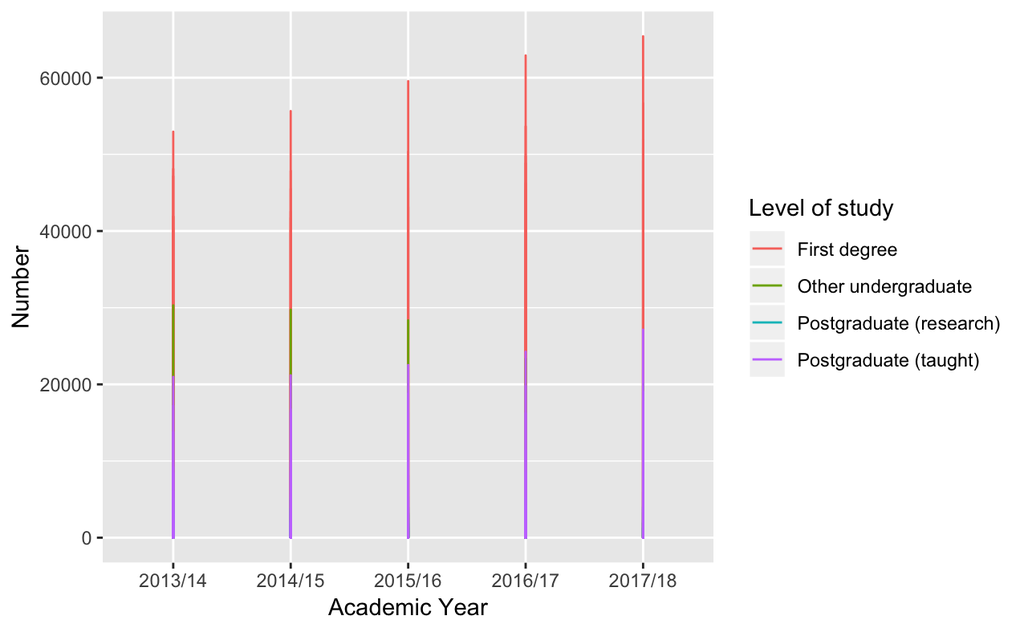

```r
#1
df %>%
  ggplot(aes(x=`Academic Year`, y=Number, colour=`Level of study`)) +
  geom_line()
```

```r
#2
df <- df %>%
  mutate(Year = as.numeric(substring(`Academic Year`, 1, 4)) + 1)
df
```

| Subject Area | First year marker | Level of study | Mode of study | Country of HE provider | Sex | Academic Year | Number | Year |
| --- | --- | --- | --- | --- | --- | --- | --- | --- |
| (1) Medicine & dentistry | First year | Postgraduate (research) | Full-time | England | Female | 2013/14 | 1045 | 2014 |
| (1) Medicine & dentistry | First year | Postgraduate (research) | Full-time | England | Male | 2013/14 | 760 | 2014 |
| (1) Medicine & dentistry | First year | Postgraduate (research) | Full-time | England | Other | 2013/14 | 0 | 2014 |
| (1) Medicine & dentistry | First year | Postgraduate (research) | Full-time | England | Female | 2014/15 | 1075 | 2015 |
| (1) Medicine & dentistry | First year | Postgraduate (research) | Full-time | England | Male | 2014/15 | 790 | 2015 |
| (1) Medicine & dentistry | First year | Postgraduate (research) | Full-time | England | Other | 2014/15 | 0 | 2015 |
| (1) Medicine & dentistry | First year | Postgraduate (research) | Full-time | England | Female | 2015/16 | 1135 | 2016 |
| (1) Medicine & dentistry | First year | Postgraduate (research) | Full-time | England | Male | 2015/16 | 765 | 2016 |
| (1) Medicine & dentistry | First year | Postgraduate (research) | Full-time | England | Other | 2015/16 | 0 | 2016 |
| (1) Medicine & dentistry | First year | Postgraduate (research) | Full-time | England | Female | 2016/17 | 1000 | 2017 |

[output cut: 990 more lines]

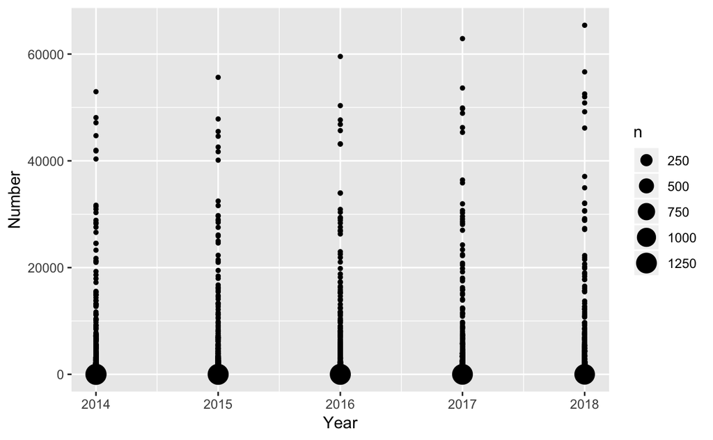

```r
#3
df %>%
  ggplot(aes(x=Year, y=Number)) +
  geom_point(stat="sum")
```

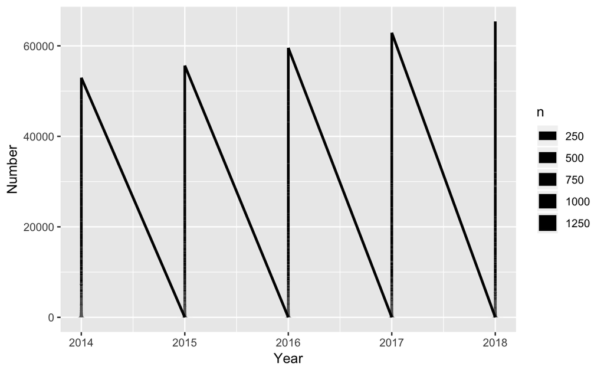

```r
#4 ??
df %>%
  ggplot(aes(x=Year, y=Number)) +
  geom_line(stat="sum")
```

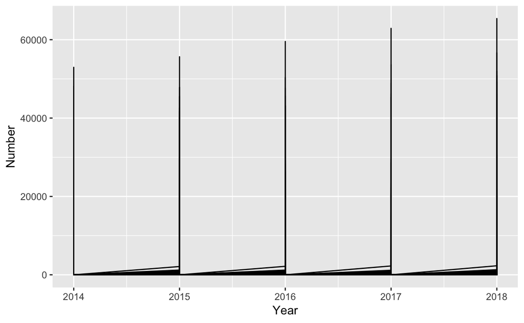

```r
#5 ???
df %>%
  ggplot(aes(x=Year, y=Number, group=`Subject Area`)) +
  geom_line()
```

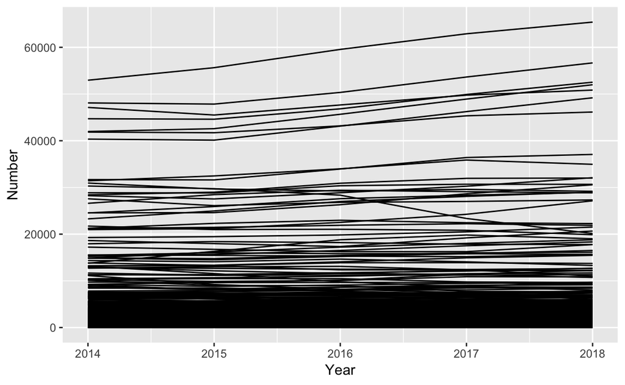

```r
#6. Right shape now (no sawtooth, unlike #5), but how do I get the aggregated lines that I want?
df %>%
  ggplot(aes(x=Year, y=Number, group=interaction(`Subject Area`, `First year marker`, `Level of study`, `Mode of study`, `Country of HE provider`, Sex))) +
  geom_line()
```

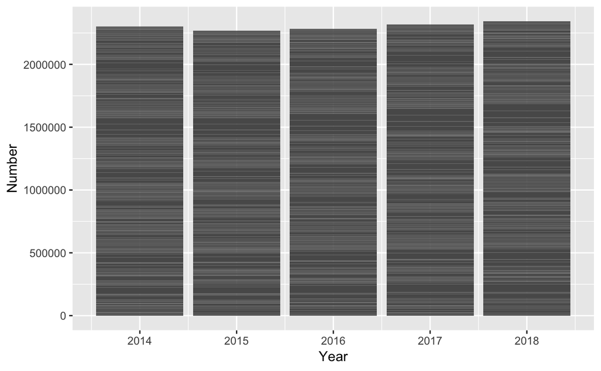

```r
#7
df %>%
  ggplot(aes(x=Year, y=Number)) +
  geom_bar(stat = "identity")
```

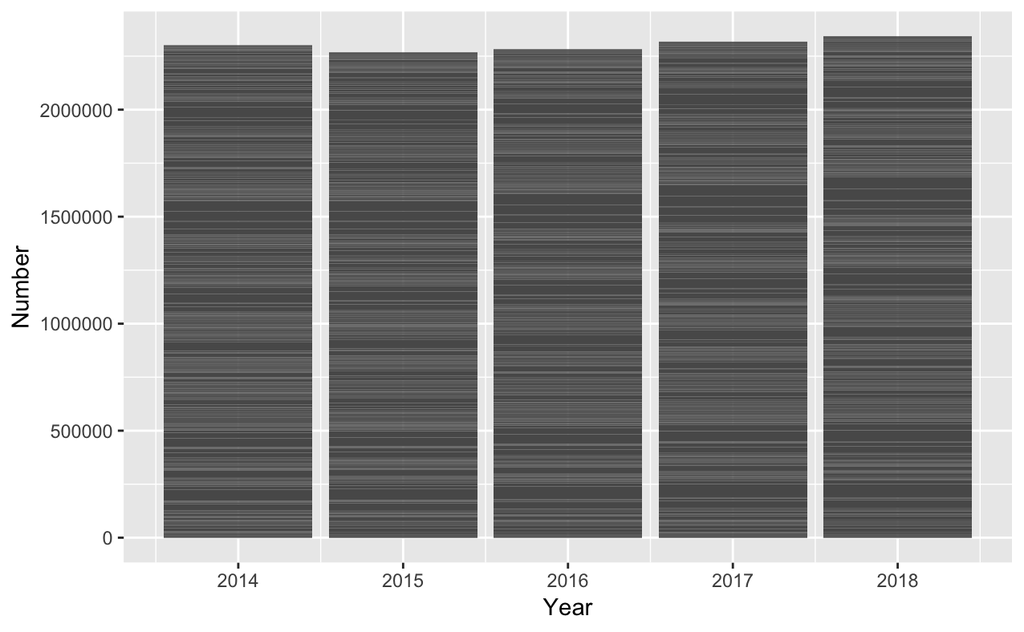

```r
#8. Same outcome as #7
df %>%
  ggplot(aes(x=Year, y=Number)) +
  geom_col()
```

Why does Chart #5 still have vertical lines (after defining `group=`)? And although Chart #6 got rid of the vertical lines, how to I get the few/aggregate lines that I want to see?